# Hedonic Home Price Prediction

Al-Jalil Gault & Ejirooghene Ojeni, Master of City Planning, ’21

October 15, 2020

## Introduction

The purpose of this project is to create an efficient, data-driven way to predict home sale price in Miami, FL for the company Zillow. Today, the real estate market is very subjective. The factors that influence the price of a home vary across region and neighborhood, so it becomes a difficult task to assess. Additionally, the use of data science can help with operational efficiency because, if you can program an algorithm to make predictions for a municipality, this alleviates the cost of sending property assessors across the entire city.

Generally, there are three types of variables which impact the sale price of a home. Those include: Internal Characteristics, Public Amenities and Services, and Spatial Structure. Internal characteristics are features of a home such as number of bedrooms or bathrooms. Public amenities and services are things like access to a beach or public transportation. Spatial structure variables are spatial occurrences, such as neighborhood culture, population, or distance to water.

This project uses these types of variables to identify factors that influence home sale price most significantly. The results of this model must substantially improve before it is ready for civic use. This report features some of the successes with predictive variables as well as ways to check for the most equitable deployment possible.

### Visualize Home Price in Miami

First, we will visualize Home Prive throughout Miami and Miami Beach.

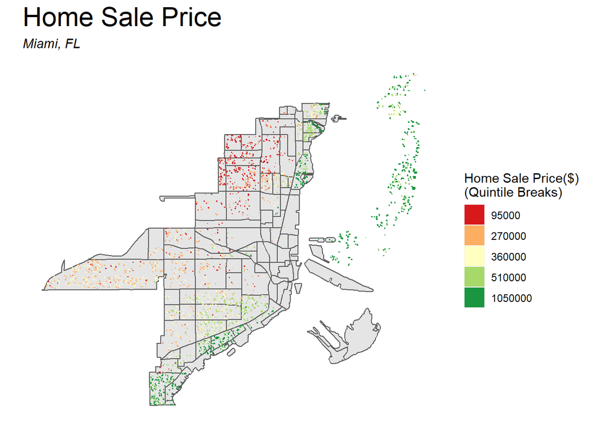

```r
dat <- st_read("C:/Users/gault/OneDrive/UPenn/Third Semester/Public Policy Analytics/Homework 2/data/studentsData.geojson") %>%
  st_transform('ESRI:102728')
neighborhoods <- st_read("C:/Users/gault/OneDrive/UPenn/Third Semester/Public Policy Analytics/Homework 2/data/neighborhoods.shp") %>%
  st_transform(st_crs(dat))

dat_to_model <- dat %>% dplyr::filter(dat$SalePrice >= 12500, Mailing.State == "FL", dat$toPredict == 0)

ggplot() +
  geom_sf(data = neighborhoods ) +
  geom_sf(data = dat_to_model, aes(fill = q5(SalePrice), color = q5(SalePrice))) +
  scale_fill_manual(values = c("#d7191c", "#fdae61", "#ffffbf", "#a6d96a", "#1a9641"),
                    name = "Home Sale Price($)\n(Quintile Breaks)",
                    labels = qBr(dat_to_model, "SalePrice")) +
  scale_color_manual(values = c("#d7191c", "#fdae61", "#ffffbf", "#a6d96a", "#1a9641"),
                     name = "Home Sale Price($)\n(Quintile Breaks)",
                     labels = qBr(dat_to_model, "SalePrice")) +
  labs(title = "Home Sale Price", subtitle = "Miami, FL") +
  mapTheme() + theme(plot.title = element_text(size=22))
```

## Gathering Data and Presenting Variables

Gathering data for this project involved storing internal characteristics as variables, downloading public services and amenities from Miami’s open data site, as well as downloading census data for spatial structure variables. We use the following variables:

| Internal Characteristics | Public Amenities | Spatial structure |
| --- | --- | --- |
| Square Footage | Distance to Neearest Beach | Distance to Water |
| Number of Bedrooms | Distance to Scenic Transportation | Neighborhoods |
| Number of Bathrooms | Distance to Private Schools | Being within Miami Beach |
| Number of Floors in a house |  | Population Density of the Home’s Census Tract |
| Effective Year Built |  | Median Household Income of the Home’s Census Tract |
| Presence of a Pool |  | Educational Attainment of the Home’s Census Tact |
| Presence of a wading Pool |  |  |
| Presence of an Average Pool |  |  |
| Presence of an Average 6’ Pool |  |  |
| Presence of a better 6’ Pool |  |  |
| Presence of an 8’ Pool |  |  |
| Presence of a Luxury Pool |  |  |
| Presence of a Better Luxury Pool |  |  |
| Presence of the Best Luxury Pool |  |  |
| Presence of a Whirlpool |  |  |
| Presence of a Jacuzzi |  |  |
| Presence of a Patio |  |  |
| Presence of a Patio with Exotic Wood |  |  |
| Presence of a Patio made of Terrazo |  |  |
| Presence of an Iron Fence |  |  |
| Presence of a Wood Fence |  |  |
| Presence of a Chain-link Fence |  |  |
| Presence of a Glass Fence |  |  |
| Presence of a Gazebo |  |  |
| Presence of a Carport |  |  |
| Presence of a Bomb Shelter |  |  |
| Presence of an Elevator |  |  |
| Presence of a Central AC |  |  |
| Presence of a Dock |  |  |
| Presence of a Tiki Hut |  |  |
| Presence of a Reinforced Concrete Wall |  |  |
| Presence of an Unreinforced Concrete Wall |  |  |
| Presence of a Slat House |  |  |
| Presence of a Tennis Court |  |  |

```r
###### Feature Engineering

### Special attributes
dat$pool <- ifelse((grepl("Pool", dat$XF1, fixed = TRUE) |
                    grepl("Pool", dat$XF2, fixed = TRUE) |
                    grepl("Pool", dat$XF3, fixed = TRUE) ),
                   1, 0)

dat$pool_wading <- ifelse((grepl("Pool - Wading", dat$XF1, fixed = TRUE) |
                           grepl("Pool - Wading", dat$XF2, fixed = TRUE) |
                           grepl("Pool - Wading", dat$XF3, fixed = TRUE) ),
                            1, 0)

dat$pool_comm_avg <- ifelse((grepl("Pool COMM AVG", dat$XF1, fixed = TRUE) |
                             grepl("Pool COMM AVG", dat$XF2, fixed = TRUE) |
                             grepl("Pool COMM AVG", dat$XF3, fixed = TRUE) ),
                         1, 0)

dat$pool_6_avg <- ifelse((grepl("Pool 6' res AVG", dat$XF1, fixed = TRUE) |
                          grepl("Pool 6' res AVG", dat$XF2, fixed = TRUE) |
                          grepl("Pool 6' res AVG", dat$XF3, fixed = TRUE) ),
                   1, 0)

dat$pool_6_better <- ifelse((grepl("Pool 6' res BETTER", dat$XF1, fixed = TRUE) |
                             grepl("Pool 6' res BETTER", dat$XF2, fixed = TRUE) |
                             grepl("Pool 6' res BETTER", dat$XF3, fixed = TRUE) ),
                         1, 0)

dat$pool_8_better <- ifelse((grepl("Pool 8' res BETTER", dat$XF1, fixed = TRUE) |
                             grepl("Pool 8' res BETTER", dat$XF2, fixed = TRUE) |
                             grepl("Pool 8' res BETTER", dat$XF3, fixed = TRUE) ),
                            1, 0)


dat$luxury_pool_good <- ifelse((grepl("Luxury Pool - Good", dat$XF1, fixed = TRUE) |
                                grepl("Luxury Pool - Good", dat$XF2, fixed = TRUE) |
                                grepl("Luxury Pool - Good", dat$XF3, fixed = TRUE) ),
                               1, 0)

dat$luxury_pool_better <- ifelse((grepl("Luxury Pool - Better", dat$XF1, fixed = TRUE) |
                                  grepl("Luxury Pool - Better", dat$XF2, fixed = TRUE) |
                                  grepl("Luxury Pool - Better", dat$XF3, fixed = TRUE) ),
                                 1, 0)

dat$luxury_pool_best <- ifelse((grepl("Luxury Pool - Best", dat$XF1, fixed = TRUE) |
                                grepl("Luxury Pool - Best", dat$XF2, fixed = TRUE) |
                                grepl("Luxury Pool - Best", dat$XF3, fixed = TRUE) ),
                               1, 0)

dat$whirlpool <- ifelse((grepl("Whirlpool", dat$XF1, fixed = TRUE) |
                         grepl("Whirlpool", dat$XF2, fixed = TRUE) |
                         grepl("Whirlpool", dat$XF3, fixed = TRUE) ),
                   1, 0)

dat$jacuzzi <- ifelse((grepl("Jacuzzi", dat$XF1, fixed = TRUE) |
                       grepl("Jacuzzi", dat$XF2, fixed = TRUE) |
                       grepl("Jacuzzi", dat$XF3, fixed = TRUE) ),
                     1, 0)

dat$patio <- ifelse((grepl("Patio", dat$XF1, fixed = TRUE) |
                     grepl("Patio", dat$XF2, fixed = TRUE) |
                     grepl("Patio", dat$XF3, fixed = TRUE) ),
                   1, 0)

dat$exotic_patio <- ifelse((grepl("Patio - Exotic", dat$XF1, fixed = TRUE) |
                            grepl("Patio - Exotic", dat$XF2, fixed = TRUE) |
                            grepl("Patio - Exotic", dat$XF3, fixed = TRUE) ),
                           1, 0)

dat$marble_patio <- ifelse((grepl("Patio - Marble", dat$XF1, fixed = TRUE) |
                            grepl("Patio - Marble", dat$XF2, fixed = TRUE) |
                            grepl("Patio - Marble", dat$XF3, fixed = TRUE) ),
                    1, 0)

dat$terrazo_patio <- ifelse((grepl("Patio - Terrazzo", dat$XF1, fixed = TRUE) |
                             grepl("Patio - Terrazzo", dat$XF2, fixed = TRUE) |
                             grepl("Patio - Terrazzo", dat$XF3, fixed = TRUE) ),
                           1, 0)

dat$iron_fence <- ifelse((grepl("Iron Fence", dat$XF1, fixed = TRUE) |
                          grepl("Iron Fence", dat$XF2, fixed = TRUE) |
                          grepl("Iron Fence", dat$XF3, fixed = TRUE) ),
                    1, 0)

dat$wood_fence <- ifelse((grepl("Wood Fence", dat$XF1, fixed = TRUE) |
                          grepl("Wood Fence", dat$XF2, fixed = TRUE) |
                          grepl("Wood Fence", dat$XF3, fixed = TRUE) ),
                         1, 0)

dat$chain_link_fence <- ifelse((grepl("Chain-link Fence", dat$XF1, fixed = TRUE) |
                                grepl("Chain-link Fence", dat$XF2, fixed = TRUE) |
                                grepl("Chain-link Fence", dat$XF3, fixed = TRUE) ),
                         1, 0)

dat$glass_fence <- ifelse((grepl("Glass fences", dat$XF1, fixed = TRUE) |
                           grepl("Glass fences", dat$XF2, fixed = TRUE) |
                           grepl("Glass fences", dat$XF3, fixed = TRUE) ),
                               1, 0)

dat$gazebo <- ifelse((grepl("Gazebo", dat$XF1, fixed = TRUE) |
                      grepl("Gazebo", dat$XF2, fixed = TRUE) |
                      grepl("Gazebo", dat$XF3, fixed = TRUE) ),
                     1, 0)

dat$carport <- ifelse((grepl("Carport", dat$XF1, fixed = TRUE) |
                       grepl("Carport", dat$XF2, fixed = TRUE) |
                       grepl("Carport", dat$XF3, fixed = TRUE) ),
                     1, 0)

dat$bomb_shelter <- ifelse((grepl("Bomb Shelter", dat$XF1, fixed = TRUE) |
                            grepl("Bomb Shelter", dat$XF2, fixed = TRUE) |
                            grepl("Bomb Shelter", dat$XF3, fixed = TRUE) ),
                      1, 0)

dat$elevator <- ifelse((grepl("Elevator", dat$XF1, fixed = TRUE) |
                        grepl("Elevator", dat$XF2, fixed = TRUE) |
                        grepl("Elevator", dat$XF3, fixed = TRUE) ),
                           1, 0)

dat$central_ac <- ifelse((grepl("Central A/C", dat$XF1, fixed = TRUE) |
                          grepl("Central A/C", dat$XF2, fixed = TRUE) |
                          grepl("Central A/C", dat$XF3, fixed = TRUE) ),
                       1, 0)
```

```r
dat$dock <- ifelse((grepl("Dock", dat$XF1, fixed = TRUE) |
                    grepl("Dock", dat$XF2, fixed = TRUE) |
                    grepl("Dock", dat$XF3, fixed = TRUE) ),
                         1, 0)

dat$tiki_hut <- ifelse((grepl("Tiki Hut", dat$XF1, fixed = TRUE) |
                        grepl("Tiki Hut", dat$XF2, fixed = TRUE) |
                        grepl("Tiki Hut", dat$XF3, fixed = TRUE) ),
                   1, 0)

dat$screen <- ifelse((grepl("Screen Enclosure", dat$XF1, fixed = TRUE) |
                      grepl("Screen Enclosure", dat$XF2, fixed = TRUE) |
                      grepl("Screen Enclosure", dat$XF3, fixed = TRUE) ),
                       1, 0)

dat$reinforced_wall <- ifelse((grepl("reinforced", dat$XF1, fixed = TRUE) |
                               grepl("reinforced", dat$XF2, fixed = TRUE) |
                               grepl("reinforced", dat$XF3, fixed = TRUE) ),
                     1, 0)

dat$unreinforced_wall <- ifelse((grepl("unreinforced", dat$XF1, fixed = TRUE) |
                                 grepl("unreinforced", dat$XF2, fixed = TRUE) |
                                 grepl("unreinforced", dat$XF3, fixed = TRUE) ),
                              1, 0)

dat$slat_house <- ifelse((grepl("Slat House", dat$XF1, fixed = TRUE) |
                          grepl("Slat House", dat$XF2, fixed = TRUE) |
                          grepl("Slat House", dat$XF3, fixed = TRUE) ),
                                1, 0)

dat$tennis_court <- ifelse((grepl("Tennis Court", dat$XF1, fixed = TRUE) |
                            grepl("Tennis Court", dat$XF2, fixed = TRUE) |
                            grepl("Tennis Court", dat$XF3, fixed = TRUE) ),
                         1, 0)

### scenic transport
scenic_trans <- st_read ("https://opendata.arcgis.com/datasets/4047eab38c5f40408aacaab95e3b9b3a_0.geojson") %>%
  st_transform(st_crs(dat))

dat$distance_to_scenic_trans <- st_distance(dat, st_union(scenic_trans))

#plot Scenic trans distance

dat_to_model <- dat %>% dplyr::filter(dat$SalePrice >= 12500, Mailing.State == "FL")

###neighborhood

neighborhoods <- st_read("C:/Users/gault/OneDrive/UPenn/Third Semester/Public Policy Analytics/Homework 2/data/neighborhoods.shp") %>%
  st_transform(st_crs(dat))
neighborhoods$neighborhood <- neighborhoods$LABEL

dat_centroids <- st_centroid(dat)
dat_centroids <- st_join(dat_centroids, left = TRUE, neighborhoods["neighborhood"])
dat_centroids$neighborhood [which (is.na(dat_centroids$neighborhood))] <- "0"


#Add Census Data

census_api_key("e79f3706b6d61249968c6ce88794f6f556e5bf3d", overwrite = TRUE)

tracts18.2 <-
  get_acs(geography = "tract", variables = c("B19001_001E","B01003_001E","B15003_022E"),
          year=2018, state=12, county=086, geometry=T) %>%
  st_transform('ESRI:102728')

tracts18.2 <-
  tracts18.2 %>%
  dplyr::select( -NAME, -moe) %>%
  spread(variable, estimate) %>%
  dplyr::select(-geometry) %>%
  rename(TotalPop = B01003_001,
         HHIncome = B19001_001,
         BacAttain = B15003_022)

tracts18.2$Totalarea <- st_area(tracts18.2$geometry) #calculate the area of a census tract
tracts18.2$Totalarea_Miles <- tracts18.2$Totalarea / 27878400 #convert the area into units of miles
tracts18.2$PopDens <- tracts18.2$TotalPop /tracts18.2$Totalarea_Miles #calculate density as population/area


#make centroids of the houses and if centroid is in tract then add that data

dat_centroids <- st_join(dat_centroids, left = TRUE, tracts18.2["PopDens"])
dat_centroids <-st_join(dat_centroids, left = TRUE, tracts18.2["HHIncome"])
dat_centroids <- st_join(dat_centroids, left = TRUE, tracts18.2["BacAttain"])

beach <-rbind(
  st_read("https://opendata.arcgis.com/datasets/9e30807e3efd44f3b16ab8d3657249f2_0.geojson")) %>%
  st_transform(st_crs(tracts18.2))

st_c <- st_coordinates

dat_centroids <-
  dat_centroids %>%
  mutate(
    beach_nn1 = nn_function(st_c(dat_centroids), st_c(beach$geometry), 1))

#distance to water
water <-rbind(
  st_read("https://opendata.arcgis.com/datasets/58386199cc234518822e5f34f65eb713_0.geojson"
  )) %>%
  st_transform(st_crs(tracts18.2))
#water <- gIntersection(bounds, water, byid = TRUE, drop_lower_td = TRUE)
water <-st_read("C:/Users/gault/OneDrive/UPenn/Third Semester/Public Policy Analytics/Homework 2/data/water_edit.shp")

dat_centroids$d_wat<- st_distance(dat_centroids, st_union(water))

#private schools
private_schools <-rbind(
  st_read("https://opendata.arcgis.com/datasets/7fecb87ea1b1494eb2beb13906465de9_0.geojson"
  )) %>%
  st_transform(st_crs(tracts18.2))

dat_centroids$d_private_schools<- st_distance(dat_centroids, st_union(private_schools))


#miami beach
dat_centroids$miami_beach <- ifelse((dat_centroids$Property.City == "Miami Beach"), 1, 0)


### Sort Variables and Run Regressions

dat_to_predict <- dat_centroids %>% dplyr::filter(dat$toPredict == 1)
dat_to_model <- dat_centroids %>% dplyr::filter(dat$SalePrice >= 12500, Mailing.State == "FL", dat$toPredict == 0)

# set random seed, basically the name giving to a paticular way to split data
set.seed(31356)

# get index for training sample can change 60-80
inTrain <- caret::createDataPartition(
  y = paste(dat_to_model$neighborhood),
  p = .70, list = FALSE)
# split data into training and test
miami.training <- dat_to_model[inTrain,]
miami.test     <- dat_to_model[-inTrain,]

### #2, present variables in stargazer

internal_characteristics <- lm(SalePrice ~ ., data = st_drop_geometry(miami.training) %>%
                       dplyr::select(SalePrice,
                                     AdjustedSqFt,
                                     ActualSqFt,
                                     Bed,
                                     Bath,
                                     Stories,
                                     EffectiveYearBuilt,
                                     pool,
                                     pool_wading,
                                     pool_comm_avg,
                                     pool_6_avg,
                                     pool_6_better,
                                     pool_8_better,
                                     luxury_pool_good,
                                     luxury_pool_better,
                                     luxury_pool_best,
                                     whirlpool,
                                     jacuzzi,
                                     patio,
                                     exotic_patio,
                                     marble_patio,
                                     terrazo_patio,
                                     iron_fence,
                                     wood_fence,
                                     chain_link_fence,
                                     glass_fence,
                                     gazebo,
                                     carport,
                                     bomb_shelter,
                                     elevator,
                                     central_ac,
                                     dock,
                                     tiki_hut,
                                     screen,
                                     reinforced_wall,
                                     unreinforced_wall,
                                     slat_house,
                                     tennis_court
                       ))
```

```r
public_ammenities_services <- lm(SalePrice ~ ., data = st_drop_geometry(miami.training) %>%
                                  dplyr::select(SalePrice,
                                                beach_nn1,
                                                distance_to_scenic_trans,
                                                d_private_schools
                                  ))

spatial_structure <- lm(SalePrice ~ ., data = st_drop_geometry(miami.training) %>%
                                   dplyr::select(SalePrice,
                                                 d_wat,
                                                 neighborhood,
                                                 miami_beach,
                                                 PopDens,
                                                 HHIncome,
                                                 BacAttain
                                   ))
```

We In the table below, we can also see a summary of coefficients for how these variables help predict home price.

```r
pander (internal_characteristics, type="text", caption = "Internal Characteristics")
```

Internal Characteristics

|  | Estimate | Std. Error | t value | Pr(>\|t\|) |
| --- | --- | --- | --- | --- |
| **(Intercept)** | -141402 | 1374993 | -0.1028 | 0.9181 |
| **AdjustedSqFt** | 462.3 | 94.45 | 4.895 | 1.074e-06 |
| **ActualSqFt** | 287.1 | 80.01 | 3.588 | 0.0003421 |
| **Bed** | -192017 | 28332 | -6.777 | 1.658e-11 |
| **Bath** | 152351 | 30773 | 4.951 | 8.091e-07 |
| **Stories** | -220733 | 54021 | -4.086 | 4.583e-05 |
| **EffectiveYearBuilt** | -40.13 | 702.8 | -0.0571 | 0.9545 |
| **pool** | 507483 | 425239 | 1.193 | 0.2329 |
| **pool_wading** | -1236721 | 558169 | -2.216 | 0.02684 |
| **pool_comm_avg** | -319321 | 513400 | -0.622 | 0.534 |
| **pool_6_avg** | -700704 | 434943 | -1.611 | 0.1074 |
| **pool_6_better** | -500323 | 422799 | -1.183 | 0.2368 |
| **pool_8_better** | 287182 | 431705 | 0.6652 | 0.506 |
| **luxury_pool_good** | 2856068 | 458459 | 6.23 | 5.815e-10 |
| **luxury_pool_better** | 6535364 | 547704 | 11.93 | 1.24e-31 |
| **luxury_pool_best** | 10606109 | 998352 | 10.62 | 1.323e-25 |
| **whirlpool** | -339394 | 111625 | -3.04 | 0.002396 |
| **jacuzzi** | -676439 | 220721 | -3.065 | 0.002212 |
| **patio** | -40733 | 37008 | -1.101 | 0.2712 |
| **exotic_patio** | -203833 | 520214 | -0.3918 | 0.6952 |
| **marble_patio** | -464492 | 252524 | -1.839 | 0.06602 |
| **terrazo_patio** | 248811 | 97177 | 2.56 | 0.01054 |
| **iron_fence** | -115456 | 80364 | -1.437 | 0.151 |
| **wood_fence** | -69636 | 43454 | -1.603 | 0.1092 |
| **chain_link_fence** | -22217 | 38500 | -0.5771 | 0.564 |
| **glass_fence** | 266495 | 530848 | 0.502 | 0.6157 |
| **gazebo** | 258801 | 216095 | 1.198 | 0.2312 |
| **carport** | -30480 | 72608 | -0.4198 | 0.6747 |
| **elevator** | 3397366 | 235849 | 14.4 | 1.383e-44 |
| **central_ac** | 568040 | 724542 | 0.784 | 0.4331 |
| **dock** | 1070019 | 108446 | 9.867 | 2.144e-22 |
| **tiki_hut** | 24064 | 363662 | 0.06617 | 0.9472 |
| **screen** | -205721 | 161626 | -1.273 | 0.2032 |
| **reinforced_wall** | -197263 | 116995 | -1.686 | 0.09195 |
| **unreinforced_wall** | 159507 | 131353 | 1.214 | 0.2248 |
| **slat_house** | 186757 | 511239 | 0.3653 | 0.7149 |
| **tennis_court** | -1750810 | 755080 | -2.319 | 0.02052 |

```r
pander (public_ammenities_services, type="text", caption = "Public Amenities/Services")
```

Public Amenities/Services

|  | Estimate | Std. Error | t value | Pr(>\|t\|) |
| --- | --- | --- | --- | --- |
| **(Intercept)** | 1224382 | 118918 | 10.3 | 3.348e-24 |
| **beach_nn1** | -67.92 | 4.582 | -14.82 | 5.057e-47 |
| **distance_to_scenic_trans** | 37.43 | 5.66 | 6.614 | 4.92e-11 |
| **d_private_schools** | 325.8 | 33.78 | 9.646 | 1.656e-21 |

```r
pander (spatial_structure, type="text", caption = "Spatial Structures")
```

Spatial Structures

|  | Estimate | Std. Error | t value | Pr(>\|t\|) |
| --- | --- | --- | --- | --- |
| **(Intercept)** | 3177042 | 189073 | 16.8 | 7.487e-59 |
| **d_wat** | -31.69 | 33.84 | -0.9364 | 0.3492 |
| **neighborhood79th Street** | -1132147 | 1575126 | -0.7188 | 0.4724 |
| **neighborhoodAllapattah Industrial District** | -902037 | 1006671 | -0.8961 | 0.3703 |
| **neighborhoodAuburndale** | -973066 | 575793 | -1.69 | 0.09121 |
| **neighborhoodBay Heights** | -1485204 | 504940 | -2.941 | 0.003311 |
| **neighborhoodBaypoint** | -371272 | 406158 | -0.9141 | 0.3608 |
| **neighborhoodBayside** | -1937379 | 372519 | -5.201 | 2.218e-07 |
| **neighborhoodBelle Island** | 1019031 | 797807 | 1.277 | 0.2017 |
| **neighborhoodBelle Meade** | -1646053 | 319487 | -5.152 | 2.866e-07 |
| **neighborhoodBelle Meade West** | -2088946 | 480222 | -4.35 | 1.44e-05 |
| **neighborhoodBird Grove East** | -1645009 | 629623 | -2.613 | 0.00906 |
| **neighborhoodBird Grove West** | -1672928 | 598780 | -2.794 | 0.005265 |
| **neighborhoodBiscayne Island** | 3573553 | 1125394 | 3.175 | 0.001523 |
| **neighborhoodBiscayne Plaza** | -1930851 | 1567445 | -1.232 | 0.2182 |
| **neighborhoodBrentwood** | -2119960 | 923668 | -2.295 | 0.02184 |
| **neighborhoodBuena Vista Heights** | -1499952 | 477332 | -3.142 | 0.001704 |
| **neighborhoodBuena Vista West** | -1522923 | 363109 | -4.194 | 2.877e-05 |
| **neighborhoodCitrus Grove** | -1044308 | 573020 | -1.822 | 0.06856 |
| **neighborhoodCivic Center** | -988200 | 987359 | -1.001 | 0.317 |
| **neighborhoodCoral Gate** | -1453158 | 490475 | -2.963 | 0.00309 |
| **neighborhoodCurtis Park** | -610508 | 703568 | -0.8677 | 0.3857 |
| **neighborhoodDouglas Park** | -1066037 | 433000 | -2.462 | 0.01391 |
| **neighborhoodEast Grove** | -1314416 | 276845 | -4.748 | 2.224e-06 |
| **neighborhoodEast Little Havana** | -175125 | 645091 | -0.2715 | 0.7861 |
| **neighborhoodEdgewater** | -1533209 | 910374 | -1.684 | 0.09233 |
| **neighborhoodEdison** | -1427756 | 349028 | -4.091 | 4.497e-05 |
| **neighborhoodFair Isle** | -1025555 | 480281 | -2.135 | 0.03287 |
| **neighborhoodFlagami** | -785141 | 650283 | -1.207 | 0.2274 |
| **neighborhoodFlora Park** | -1625303 | 505553 | -3.215 | 0.001329 |
| **neighborhoodGrove Center** | -1270165 | 710153 | -1.789 | 0.07386 |
| **neighborhoodHadley Park** | -1384185 | 380531 | -3.638 | 0.0002833 |
| **neighborhoodHighland Park** | -1485668 | 934516 | -1.59 | 0.1121 |
| **neighborhoodHistoric Buena Vista East** | -1870177 | 594356 | -3.147 | 0.00168 |
| **neighborhoodKing Heights** | -1351272 | 471788 | -2.864 | 0.004231 |
| **neighborhoodLa Pastorita** | -998170 | 820932 | -1.216 | 0.2242 |
| **neighborhoodLatin Quarter** | 466032 | 1161273 | 0.4013 | 0.6882 |
| **neighborhoodLe Jeune Gardens** | -1389651 | 1711986 | -0.8117 | 0.4171 |
| **neighborhoodLemon City/Little Haiti** | -1806720 | 457705 | -3.947 | 8.215e-05 |
| **neighborhoodLiberty Square** | -1406133 | 444258 | -3.165 | 0.001577 |
| **neighborhoodLittle River Central** | -1187785 | 551108 | -2.155 | 0.03128 |
| **neighborhoodLittle River Gardens** | -1311770 | 1125855 | -1.165 | 0.2441 |
| **neighborhoodMelrose** | -887535 | 679439 | -1.306 | 0.1916 |
| **neighborhoodMiami Avenue** | -1252695 | 561188 | -2.232 | 0.02573 |
| **neighborhoodMorningside** | -2104719 | 288612 | -7.293 | 4.59e-13 |
| **neighborhoodNorth Grapeland Heights** | -986252 | 738866 | -1.335 | 0.1821 |
| **neighborhoodNorth Grove** | -1963093 | 321515 | -6.106 | 1.258e-09 |
| **neighborhoodNorth Sewell Park** | -1008343 | 692441 | -1.456 | 0.1455 |
| **neighborhoodNortheast Overtown** | -1341788 | 927879 | -1.446 | 0.1483 |
| **neighborhoodNorthwestern Estates** | -1407968 | 426212 | -3.303 | 0.0009743 |
| **neighborhoodOakland Grove** | -1266986 | 1575689 | -0.8041 | 0.4215 |
| **neighborhoodOld San Juan** | -1401118 | 445805 | -3.143 | 0.001701 |
| **neighborhoodOrange Bowl** | -8223 | 1047100 | -0.007853 | 0.9937 |
| **neighborhoodOrchard Villa** | -1348880 | 498306 | -2.707 | 0.006857 |
| **neighborhoodPalm Grove** | -2331800 | 908614 | -2.566 | 0.01036 |
| **neighborhoodParkdale North** | -993185 | 583052 | -1.703 | 0.08867 |
| **neighborhoodParkdale South** | -1592483 | 531506 | -2.996 | 0.002772 |
| **neighborhoodRoads** | -1486446 | 320534 | -4.637 | 3.79e-06 |
| **neighborhoodSan Marco Island** | 4460628 | 928428 | 4.804 | 1.684e-06 |
| **neighborhoodSanta Clara** | -1162366 | 472344 | -2.461 | 0.01396 |
| **neighborhoodShenandoah North** | -1303076 | 388199 | -3.357 | 0.0008056 |
| **neighborhoodShenandoah South** | -1654533 | 341810 | -4.841 | 1.409e-06 |
| **neighborhoodShorecrest** | -1326114 | 360923 | -3.674 | 0.0002458 |
| **neighborhoodSilver Bluff** | -1340963 | 277521 | -4.832 | 1.47e-06 |
| **neighborhoodSouth Grapeland Heights** | -584209 | 728299 | -0.8022 | 0.4226 |
| **neighborhoodSouth Grove** | -1460126 | 201923 | -7.231 | 7.134e-13 |
| **neighborhoodSouth Grove Bayside** | 985823 | 390860 | 2.522 | 0.01175 |
| **neighborhoodSouth Sewell Park** | -1098601 | 604687 | -1.817 | 0.06942 |
| **neighborhoodSpring Garden** | -1333531 | 936219 | -1.424 | 0.1545 |
| **neighborhoodWest Grapeland Heights** | -1632833 | 857364 | -1.904 | 0.05701 |
| **neighborhoodWest Grove** | -1856706 | 384212 | -4.833 | 1.466e-06 |
| **PopDens** | -58.49 | 21.17 | -2.763 | 0.005791 |
| **HHIncome** | -590.6 | 182.2 | -3.241 | 0.001211 |
| **BacAttain** | 929.5 | 270.6 | 3.434 | 0.0006076 |

### Correlation Matrix

The correlation matrix below shows that there are several variables that are colinear with one another. The results below would suggest that pool, unreinforced concrete, distance to water, and nearest beach should be removed from being in a mode together because they are colinear with Other variabes in the data. Having these in the model will skew results.

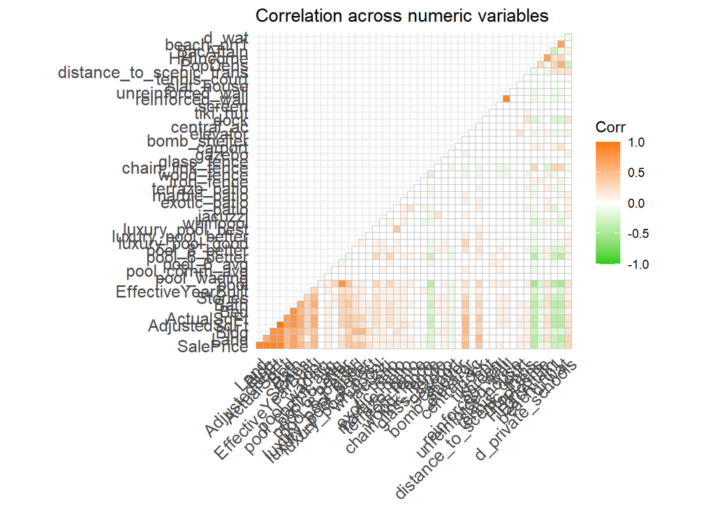

```r
#make a correlation matrix
dat_to_corr_matrix <- dat_to_model %>%
  dplyr::select(SalePrice,
                Land,
                Bldg,
                AdjustedSqFt,
                ActualSqFt,
                Bed,
                Bath,
                Stories,
                EffectiveYearBuilt,
                pool,
                pool_wading,
                pool_comm_avg,
                pool_6_avg,
                pool_6_better,
                pool_8_better,
                luxury_pool_good,
                luxury_pool_better,
                luxury_pool_best,
                whirlpool,
                jacuzzi,
                patio,
                exotic_patio,
                marble_patio,
                terrazo_patio,
                iron_fence,
                wood_fence,
                chain_link_fence,
                glass_fence,
                gazebo,
                carport,
                bomb_shelter,
                elevator,
                central_ac,
                dock,
                tiki_hut,
                screen,
                reinforced_wall,
                unreinforced_wall,
                slat_house,
                tennis_court,
                distance_to_scenic_trans,
                PopDens,
                HHIncome,
                BacAttain,
                beach_nn1,
                d_wat,
                d_private_schools) %>%
  na.omit()

dat_to_corr_matrix <- st_drop_geometry(dat_to_corr_matrix)

ggcorrplot(
  round(cor(dat_to_corr_matrix), 1),
  p.mat = cor_pmat(dat_to_corr_matrix),
  colors = c("#25CB10", "white", "#FA7800"),
  type="lower",
  insig = "blank") +
  labs(title = "Correlation across numeric variables")
```

### Variables of Interest: Correlation with Price

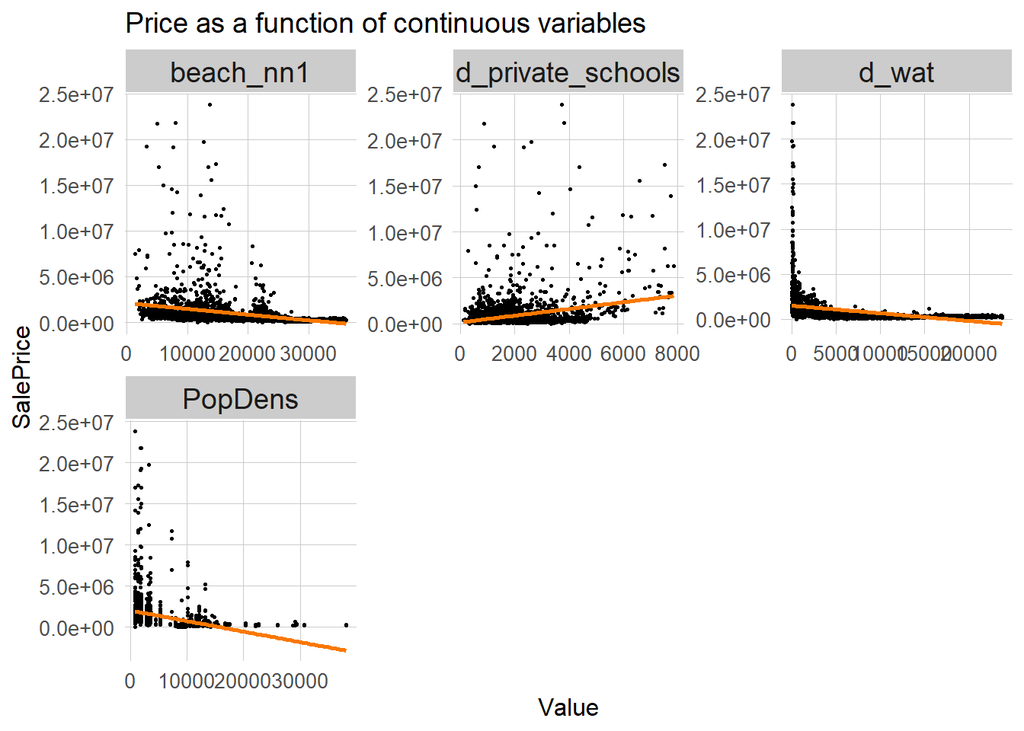

```r
st_drop_geometry(dat_to_model) %>%
  dplyr::select(SalePrice, d_wat, d_private_schools, PopDens, beach_nn1) %>% #add a fourth variable
  gather(Variable, Value, -SalePrice) %>%
  ggplot(aes(Value, SalePrice)) +
  geom_point(size = .5) + geom_smooth(method = "lm", se=F, colour = "#FA7800") +
  facet_wrap(~Variable, ncol = 3, scales = "free") +
  labs(title = "Price as a function of continuous variables") +
  plotTheme()
```

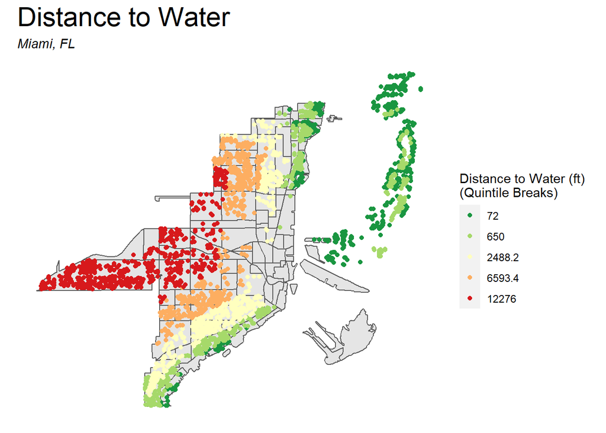

```r
# 3 interesting variables

#distance to water
ggplot() +
  geom_sf(data = neighborhoods) +
  geom_sf(data = dat_centroids, aes(fill = q5(d_wat), color = q5(d_wat))) +
  scale_fill_manual(values = rev(c("#d7191c", "#fdae61", "#ffffbf", "#a6d96a", "#1a9641")),
                    name = "Distance to Water (ft)\n(Quintile Breaks)",
                    labels = qBr(dat_centroids, "d_wat")) +
  scale_color_manual(values = rev(c("#d7191c", "#fdae61", "#ffffbf", "#a6d96a", "#1a9641")),
                     name = "Distance to Water (ft)\n(Quintile Breaks)",
                     labels = qBr(dat_centroids, "d_wat")) +
  labs(title = "Distance to Water", subtitle = "Miami, FL") +
  mapTheme() + theme(plot.title = element_text(size=22))
```

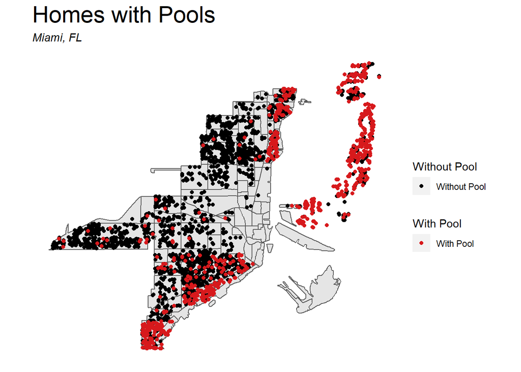

```r
#map of pools

dat_with_pool <- dat_centroids %>%
  dplyr::filter(pool == 1)

dat_without_pool <- dat_centroids %>%
  dplyr::filter(pool == 0)

ggplot() +
  geom_sf(data = neighborhoods) +
  geom_sf(data = dat_without_pool, aes(fill = "#1a9641")) +
  scale_fill_manual(values = "#1a9641",
                    name = "Without Pool",
                    label = "Without Pool") +
  labs(title = "Homes with Pools", subtitle = "Miami, FL") +
  geom_sf(data = dat_with_pool, aes(color = "#d7191c")) +
  scale_color_manual(values = "#d7191c",
                     name = "With Pool",
                     label = "With Pool") +
  mapTheme() + theme(plot.title = element_text(size=22))
```

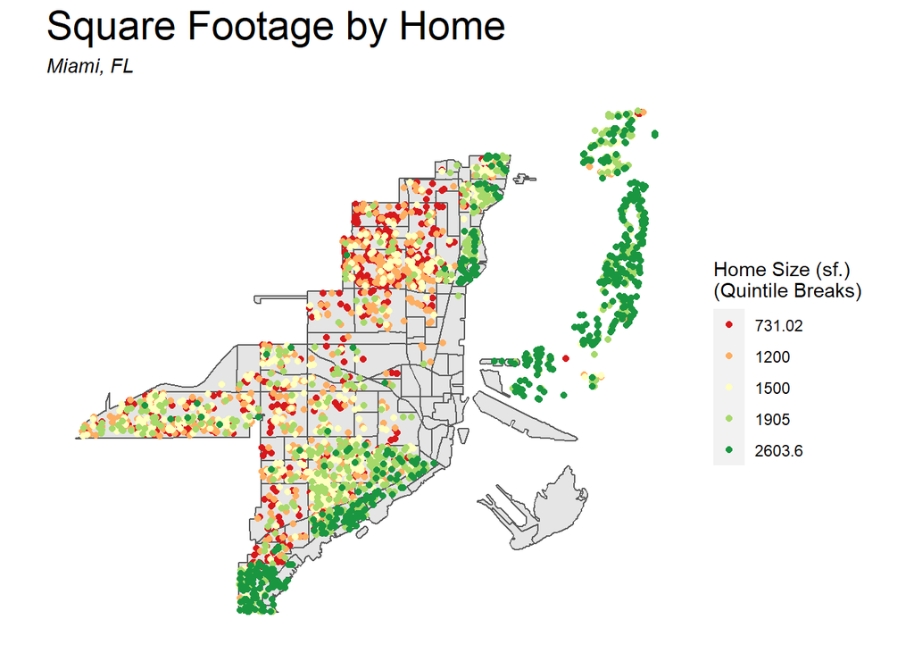

```r
#map of Adjusted Square Feet

ggplot() +
  geom_sf(data = neighborhoods) +
  geom_sf(data = dat_centroids, aes(fill = q5(AdjustedSqFt), color = q5(AdjustedSqFt))) +
  scale_fill_manual(values = c("#d7191c", "#fdae61", "#ffffbf", "#a6d96a", "#1a9641"),
                    name = "Home Size (sf.)\n(Quintile Breaks)",
                    labels = qBr(dat_centroids, "AdjustedSqFt")) +
  scale_color_manual(values = c("#d7191c", "#fdae61", "#ffffbf", "#a6d96a", "#1a9641"),
                     name = "Home Size (sf.)\n(Quintile Breaks)",
                     labels = qBr(dat_centroids, "AdjustedSqFt")) +
  labs(title = "Square Footage by Home", subtitle = "Miami, FL") +
  mapTheme() + theme(plot.title = element_text(size=22))
```

## Methods

In order to predict Sale Price, we first built and tested an algorithm which recognizes features of a home that would make it more likely to have a higher or lower price. In order to select which variables would become a part of this model, we used a “training” dataset to recognize variables with strong correlation to Sale Price, and testing this model on a “testing” dataset, which has all the same features, but on a set of homes the model hasn’t yet predicted for.

We’re able to assess the overall performance of these algorithms be creating an average error in home price (plus or minus $20,000, for example). This error is known hereafter as **Mean Absolute Error (MAE)** or **Mean Absolute Percentage Error (MAPE)**. A lower average error in predicted home prices from the testing dataset would suggest that the model we create is strong. A higher error would suggest that the model is very weak.

After building a predictive model that performs to satisfaction, we will test the “generalizability” of the model. This can be understood as the ability of the model to predict sale price with the same level of confidence (or equally distributed error) for any house, neighborhood, income group, or racial group.

## Results

Overall, the results of this model are poor. The results of this model are very poor. This model predicts home price with an average error of **$374,794.20**.

```r
##split the data into a training set and a test set

dat_to_predict <- dat_centroids %>% dplyr::filter(dat$toPredict == 1)
dat_to_model <- dat_centroids %>% dplyr::filter(dat$SalePrice >= 12500, Mailing.State == "FL", dat$toPredict == 0)

# set random seed, basically the name giving to a paticular way to split data
set.seed(31356)

# get index for training sample can change 60-80
inTrain <- caret::createDataPartition(
  y = paste(dat_to_model$neighborhood),
  p = .70, list = FALSE)
# split data into training and test
miami.training <- dat_to_model[inTrain,]
miami.test     <- dat_to_model[-inTrain,]

#### Create the regression

reg1 <- lm(SalePrice ~ ., data = st_drop_geometry(miami.training) %>%
             dplyr::select(SalePrice,
                           AdjustedSqFt,
                           ActualSqFt,
                           Bed,
                           Bath,
                           Stories,
                           EffectiveYearBuilt,
                           pool,
                           pool_wading,
                           pool_comm_avg,
                           pool_6_avg,
                           pool_6_better,
                           pool_8_better,
                           luxury_pool_good,
                           luxury_pool_better,
                           luxury_pool_best,
                           whirlpool,
                           jacuzzi,
                           patio,
                           exotic_patio,
                           marble_patio,
                           terrazo_patio,
                           iron_fence,
                           wood_fence,
                           chain_link_fence,
                           glass_fence,
                           gazebo,
                           carport,
                           bomb_shelter,
                           elevator,
                           central_ac,
                           dock,
                           tiki_hut,
                           screen,
                           reinforced_wall,
                           unreinforced_wall,
                           slat_house,
                           tennis_court,
                           PopDens,
                           HHIncome,
                           BacAttain,
                           beach_nn1,
                           d_wat,
                           neighborhood,
                           miami_beach,
                           d_private_schools))
pander(reg1)
```

Fitting linear model: SalePrice ~ .

|  | Estimate | Std. Error | t value | Pr(>\|t\|) |
| --- | --- | --- | --- | --- |
| **(Intercept)** | 627090 | 1387180 | 0.4521 | 0.6513 |
| **AdjustedSqFt** | 377.9 | 92.72 | 4.075 | 4.807e-05 |
| **ActualSqFt** | 357.9 | 79.32 | 4.512 | 6.854e-06 |
| **Bed** | -195631 | 28264 | -6.922 | 6.292e-12 |
| **Bath** | 120671 | 30228 | 3.992 | 6.829e-05 |
| **Stories** | -225083 | 53964 | -4.171 | 3.185e-05 |
| **EffectiveYearBuilt** | -376.5 | 711.1 | -0.5295 | 0.5965 |
| **pool** | 295110 | 433414 | 0.6809 | 0.496 |
| **pool_wading** | -819869 | 551013 | -1.488 | 0.137 |
| **pool_comm_avg** | -24455 | 499929 | -0.04892 | 0.961 |
| **pool_6_avg** | -447389 | 442382 | -1.011 | 0.312 |
| **pool_6_better** | -326795 | 429855 | -0.7602 | 0.4472 |
| **pool_8_better** | 372600 | 435079 | 0.8564 | 0.3919 |
| **luxury_pool_good** | 2966466 | 461553 | 6.427 | 1.682e-10 |
| **luxury_pool_better** | 6257277 | 541553 | 11.55 | 8.693e-30 |
| **luxury_pool_best** | 11244810 | 969680 | 11.6 | 5.515e-30 |
| **whirlpool** | -195407 | 109965 | -1.777 | 0.07575 |
| **jacuzzi** | -573634 | 217472 | -2.638 | 0.008422 |
| **patio** | -7567 | 38339 | -0.1974 | 0.8436 |
| **exotic_patio** | -571258 | 498321 | -1.146 | 0.2518 |
| **marble_patio** | -295985 | 245598 | -1.205 | 0.2283 |
| **terrazo_patio** | 165979 | 95428 | 1.739 | 0.08216 |
| **iron_fence** | -99920 | 78260 | -1.277 | 0.2019 |
| **wood_fence** | -51040 | 42767 | -1.193 | 0.2329 |
| **chain_link_fence** | -458.7 | 38869 | -0.0118 | 0.9906 |
| **glass_fence** | 103168 | 508265 | 0.203 | 0.8392 |
| **gazebo** | 175174 | 210092 | 0.8338 | 0.4045 |
| **carport** | -20174 | 70744 | -0.2852 | 0.7755 |
| **elevator** | 3800780 | 256401 | 14.82 | 7.369e-47 |
| **central_ac** | 580754 | 695005 | 0.8356 | 0.4035 |

[output cut: 82 more lines]

```r
## Mean Square Error train and test
rmse.train <- caret::MAE(predict(reg1), miami.training$SalePrice)
rmse.test  <- caret::MAE(predict(reg1), miami.test$SalePrice)

### Mean Absolute Eror
miami.test.reg1 <-
  miami.test %>%
  mutate(SalePrice.Predict = predict(reg1, miami.test),
         SalePrice.Error = SalePrice.Predict - SalePrice,
         SalePrice.AbsError = abs(SalePrice.Predict - SalePrice),
         SalePrice.APE = (abs(SalePrice.Predict - SalePrice)) / SalePrice.Predict)

miami.test.reg1$MAE <-mean(miami.test.reg1$SalePrice.AbsError, na.rm = T)
miami.test.reg1$MAPE <- mean(miami.test.reg1$SalePrice.APE, na.rm = T)

miami.test.reg1 %>%
  st_drop_geometry %>%
  dplyr::select(MAE, MAPE) %>%
  summarize(mean(MAE),  scales::percent(mean(MAPE))) %>%
  pander()
```

| mean(MAE) | scales::percent(mean(MAPE)) |
| --- | --- |
| 374794 | 2% |

### Generalizability

Next, we will test this model for generalizability. These new tests will also help us detect if this model has price errors that are clustered with one another. Based on the histogram below, we can see that our errors are not eveny distributed along a perfect “bell curve”. Furthermore, we still have a high MAE, this time at $400,977.40. The Model also notes that 68% of our predictions of home prices errors are within $153,290.7 of one another.

```r
fitControl <- trainControl(method = "cv", number = 100)
set.seed(31356)

reg.cv <-
  train(SalePrice ~ ., data = st_drop_geometry(miami.training) %>%
     dplyr::select(SalePrice,
                   AdjustedSqFt,
                   ActualSqFt,
                   Bed,
                   Bath,
                   Stories,
                   EffectiveYearBuilt,
                   pool,
                   pool_wading,
                   pool_comm_avg,
                   pool_6_avg,
                   pool_6_better,
                   pool_8_better,
                   luxury_pool_good,
                   luxury_pool_better,
                   luxury_pool_best,
                   whirlpool,
                   jacuzzi,
                   patio,
                   exotic_patio,
                   marble_patio,
                   terrazo_patio,
                   iron_fence,
                   wood_fence,
                   chain_link_fence,
                   glass_fence,
                   gazebo,
                   carport,
                   bomb_shelter,
                   elevator,
                   central_ac,
                   dock,
                   tiki_hut,
                   screen,
                   reinforced_wall,
                   unreinforced_wall,
                   slat_house,
                   tennis_court,
                   PopDens,
                   HHIncome,
                   BacAttain,
                   beach_nn1,
                   d_wat,
                   neighborhood,
                   miami_beach,
                   d_private_schools),
   method = "lm", trControl = fitControl, na.action = na.pass)

reg.cv
```

```
## Linear Regression
##
## 1821 samples
##   45 predictor
##
## No pre-processing
## Resampling: Cross-Validated (100 fold)
## Summary of sample sizes: 1801, 1802, 1803, 1803, 1804, 1803, ...
## Resampling results:
##
##   RMSE      Rsquared   MAE
##   688081.2  0.7741656  400977.4
##
## Tuning parameter 'intercept' was held constant at a value of TRUE
```

```r
sd(reg.cv$resample[,3])
```

```
## [1] 153290.7
```

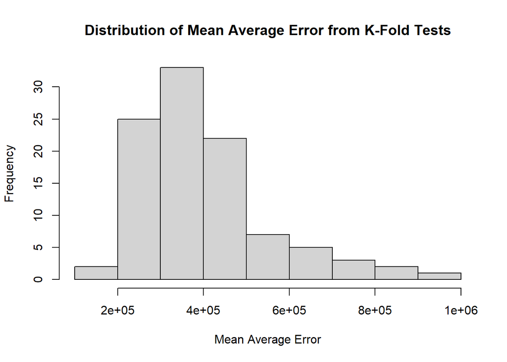

```r
hist(reg.cv$resample[,3],
     main = "Distribution of Mean Average Error from K-Fold Tests",
     xlab="Mean Average Error",
     ylab="Frequency")
```

The plot below shows predicted prices as a function of observed price. If this model were perfect, all house predictions would fall one-to-one on this plot, aligned with the black line. Our model, signified by the red line, shows that it under-predicts homes with higher values, and slightly over-predicts homes with lower values.

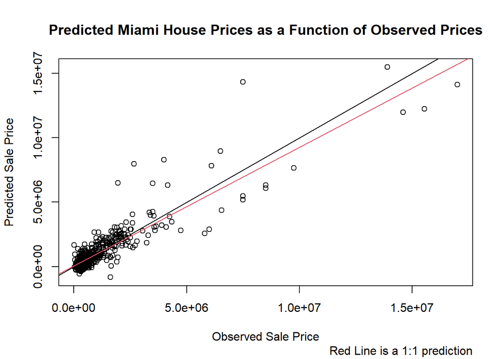

```r
plot (miami.test.reg1$SalePrice, miami.test.reg1$SalePrice.Predict,

      main = "Predicted Miami House Prices as a Function of Observed Prices",
      xlab="Observed Sale Price",
      ylab="Predicted Sale Price",
      title(sub ="Red Line is a 1:1 prediction",adj=1))
abline(0,1)
abline(lm(miami.test.reg1$SalePrice.Predict ~ miami.test.reg1$SalePrice), col = 2)
```

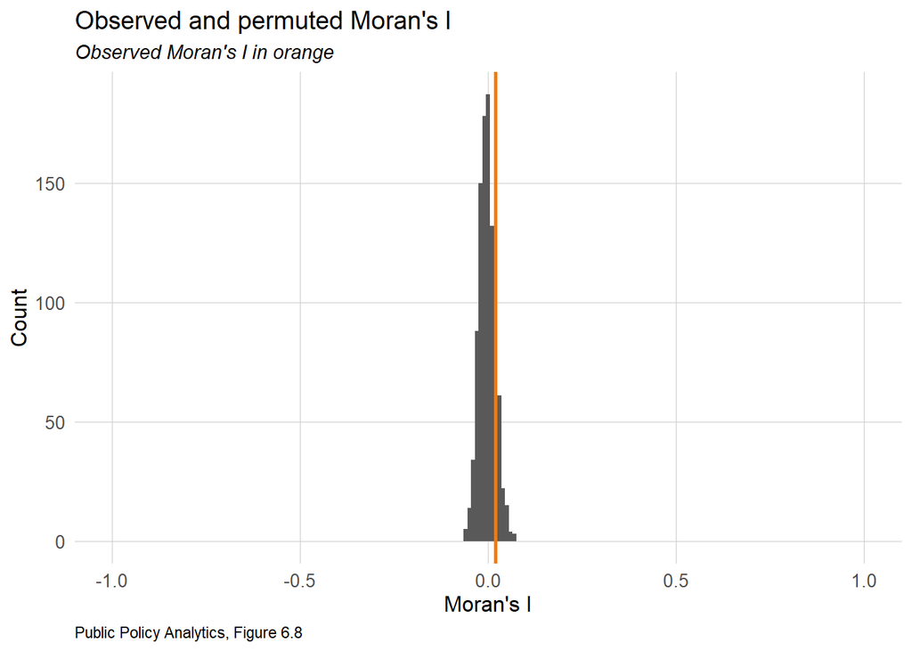

```r
#Moran's I test
coords <- st_coordinates(dat_to_model)
neighborList <- knn2nb(knearneigh(coords, 5))
spatialWeights <- nb2listw(neighborList, style="W")
dat_to_model$lagPrice <- lag.listw(spatialWeights, dat_to_model$SalePrice)
coords.test <-  st_coordinates(miami.test)
neighborList.test <- knn2nb(knearneigh(coords.test, 5))
spatialWeights.test <- nb2listw(neighborList.test, style="W")

moranTest <- moran.mc(miami.test.reg1$SalePrice.Error,
                      spatialWeights.test, nsim = 999)

ggplot(as.data.frame(moranTest$res[c(1:999)]), aes(moranTest$res[c(1:999)])) +
  geom_histogram(binwidth = 0.01) +
  geom_vline(aes(xintercept = moranTest$statistic), colour = "#FA7800",size=1) +
  scale_x_continuous(limits = c(-1, 1)) +
  labs(title="Observed and permuted Moran's I",
       subtitle= "Observed Moran's I in orange",
       x="Moran's I",
       y="Count",
       caption="Public Policy Analytics, Figure 6.8") +
  plotTheme()
```

```r
pander(moranTest)
```

Monte-Carlo simulation of Moran I: `miami.test.reg1$SalePrice.Error weights: spatialWeights.test number of simulations + 1: 1000`

| Test statistic | observed rank | P value | Alternative hypothesis |
| --- | --- | --- | --- |
| 0.02007 | 855 | 0.145 | greater |

The Price as a function of Spatial Lag Error Plot below shows that, even with spatial lag, errors continue to be disperced along lag price error.

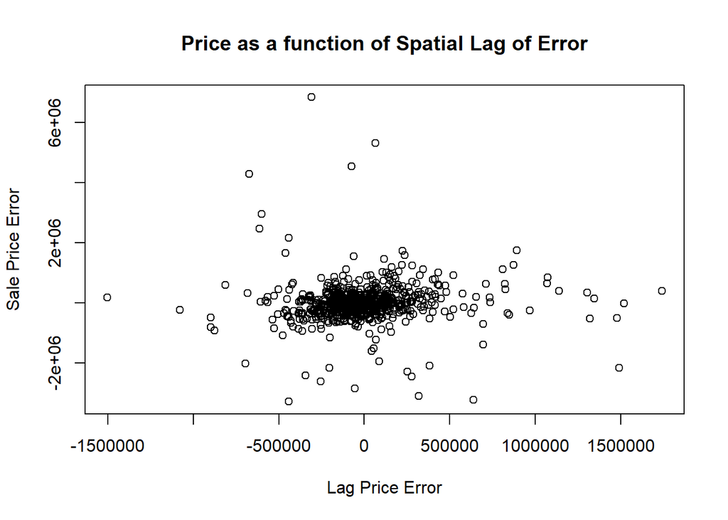

```r
#Spatial Lag of Errors Plot
coords <- st_coordinates(dat_to_model)
neighborList <- knn2nb(knearneigh(coords, 5))
spatialWeights <- nb2listw(neighborList, style="W")
dat_to_model$lagPrice <- lag.listw(spatialWeights, dat_to_model$SalePrice)

coords.test <-  st_coordinates(miami.test.reg1)
neighborList.test <- knn2nb(knearneigh(coords.test, 5))
spatialWeights.test <- nb2listw(neighborList.test, style="W")

miami.test.reg1$lagPriceError <- lag.listw((spatialWeights.test), miami.test.reg1$SalePrice.Error)

plot (miami.test.reg1$lagPriceError, miami.test.reg1$SalePrice.Error, data = miami.test.reg1,
      main = "Price as a function of Spatial Lag of Error",
      xlab="Lag Price Error",
      ylab="Sale Price Error") #is this correct?
```

This Plot shows homes to be predicted and homes which were used for this model. Many of the homes which need to be predicted are in places where home values are high.

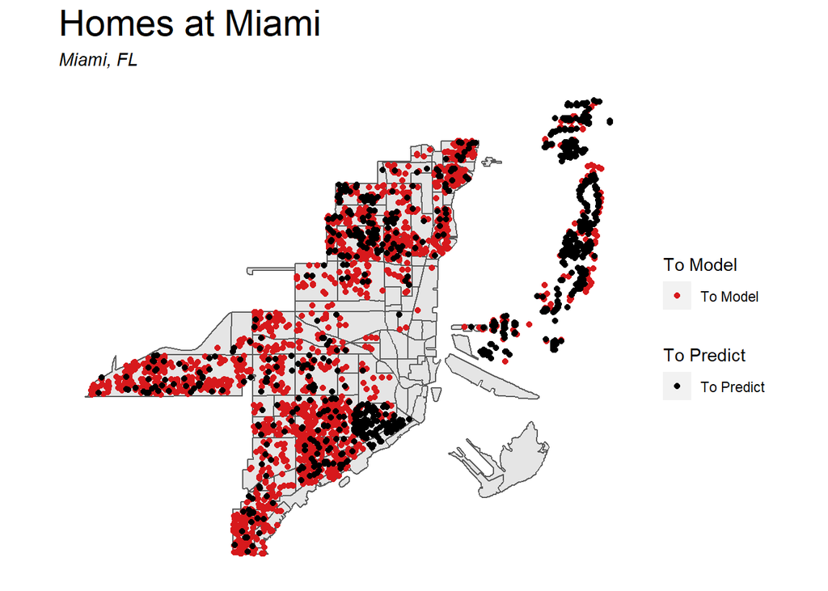

```r
ggplot() +
  geom_sf(data = neighborhoods) +
  geom_sf(data = dat_to_model, aes(color = "#d7191c")) +
  scale_color_manual(values = "#d7191c",
                     name = "To Model",
                     label = "To Model") +
  geom_sf(data = dat_to_predict, aes(fill = "#1a9641")) +
  scale_fill_manual(values = "#1a9641",
                    name = "To Predict",
                    label = "To Predict") +
  labs(title = "Homes at Miami", subtitle = "Miami, FL") +
  mapTheme() + theme(plot.title = element_text(size=22))
```

This map shows Mean Absolute Percentage Error (MAPE) by neighborhood. Homes at Miami Beach seem to be well predicted by this model (noted in a faint yellow off the coast), while homes in Miami city are pooly predicted. According to the scatter plot below the map, most neighborhoods have consistently large errors, regardless of the mean home price in that neighborhood.

```r
nhood_sum <- miami.test.reg1 %>%
  group_by(neighborhood) %>%
  summarize(meanPrice = mean(SalePrice, na.rm = T),
            meanPrediction = mean(SalePrice.Predict, na.rm = T),
            meanMAE = mean(SalePrice.AbsError, na.rm = T),
            meanMAPE=(mean(SalePrice.APE, na.rm = T)))

nhood_sum %>%
  st_drop_geometry %>%
  arrange(desc(scales::percent(meanMAE))) %>%
  pander()
```

| neighborhood | meanPrice | meanPrediction | meanMAE | meanMAPE |
| --- | --- | --- | --- | --- |
| 0 | 2735525 | 2850871 | 885744 | 0.2525 |
| South Grove Bayside | 2137500 | 1675478 | 680671 | 1.33 |
| Brentwood | 5e+05 | -122902 | 622902 | -5.068 |
| Bay Heights | 1310375 | 691977 | 618398 | 0.9956 |
| La Pastorita | 380000 | 341362 | 69699 | 0.2372 |
| Highland Park | 850000 | 799260 | 50740 | 0.06348 |
| Belle Island | 1257500 | 1749115 | 491615 | 0.2811 |
| Roads | 701423 | 712248 | 440215 | 0.8067 |
| East Little Havana | 452600 | 159137 | 407071 | -0.6962 |
| South Sewell Park | 302600 | -97370 | 4e+05 | -0.767 |
| East Grove | 1751487 | 1694503 | 389011 | 0.01707 |
| Morningside | 984286 | 895741 | 385423 | 0.5411 |
| North Grapeland Heights | 317833 | 601486 | 372983 | 0.7709 |
| Belle Meade | 690929 | 363679 | 372854 | 1.622 |
| Shorecrest | 579028 | 775118 | 352651 | 0.1066 |
| West Grove | 550056 | 546720 | 344747 | 0.3602 |
| South Grove | 1219468 | 1128195 | 332016 | 1.491 |
| Grove Center | 2237500 | 5525959 | 3288459 | 0.539 |
| South Grapeland Heights | 279167 | 118429 | 319765 | -0.8542 |
| Citrus Grove | 350529 | 465140 | 306350 | 0.3946 |
| North Grove | 1235000 | 1141111 | 303326 | -0.07446 |
| Latin Quarter | 240000 | 271209 | 31209 | 0.1151 |
| Old San Juan | 628433 | 478654 | 292461 | 0.471 |
| Miami Avenue | 1099750 | 1199420 | 291941 | 0.2803 |
| Shenandoah North | 459554 | 434822 | 288697 | -0.7663 |
| West Grapeland Heights | 353333 | 466546 | 281599 | 1.229 |
| Shenandoah South | 440441 | 512166 | 278042 | 0.6757 |
| Flagami | 335111 | 292719 | 270744 | -1.156 |
| Bird Grove West | 515000 | 262517 | 252483 | 1.138 |
| Bayside | 649556 | 615086 | 228313 | 1.01 |
| Parkdale North | 396225 | 601106 | 218381 | 0.3235 |
| Auburndale | 333286 | 244746 | 209285 | -1.495 |
| North Sewell Park | 488833 | 504304 | 209209 | -4.576 |
| Parkdale South | 377280 | 235027 | 209096 | -0.07086 |
| Douglas Park | 369409 | 225988 | 206404 | -0.1267 |
| Lemon City/Little Haiti | 264750 | 270786 | 202384 | -0.1577 |
| Little River Central | 169250 | 176254 | 197891 | -0.0351 |
| Curtis Park | 302500 | 495589 | 193089 | 0.3337 |
| Flora Park | 209086 | 251318 | 183386 | -0.2024 |
| Edison | 202144 | 2e+05 | 177684 | -1.644 |
| Silver Bluff | 484456 | 393483 | 177011 | 0.5782 |
| Fair Isle | 3341250 | 1687270 | 1653980 | -0.05147 |
| Buena Vista Heights | 348600 | 289391 | 168686 | -3.401 |
| Belle Meade West | 479500 | 560666 | 166375 | 0.368 |
| King Heights | 212988 | 321959 | 164015 | 1.607 |
| Historic Buena Vista East | 591667 | 637366 | 162930 | 0.2394 |
| Buena Vista West | 319077 | 198317 | 161491 | 0.8329 |
| Melrose | 265640 | 204421 | 156998 | -6.008 |
| Liberty Square | 135382 | 85416 | 156528 | 2.507 |
| Coral Gate | 535000 | 657116 | 143606 | 0.1978 |
| Palm Grove | 4e+05 | 258949 | 141051 | 0.5447 |
| Bird Grove East | 598333 | 458809 | 139524 | 0.3828 |
| Northwestern Estates | 133722 | 213475 | 131795 | -3.797 |
| Orchard Villa | 187875 | 119862 | 129231 | -0.202 |
| Santa Clara | 231417 | 155078 | 129206 | 1.8 |
| Hadley Park | 192254 | 153915 | 121562 | -0.5737 |
| Allapattah Industrial District | 150000 | 31971 | 118029 | 3.692 |
| Baypoint | 2993333 | 2981801 | 1053921 | 6.418 |

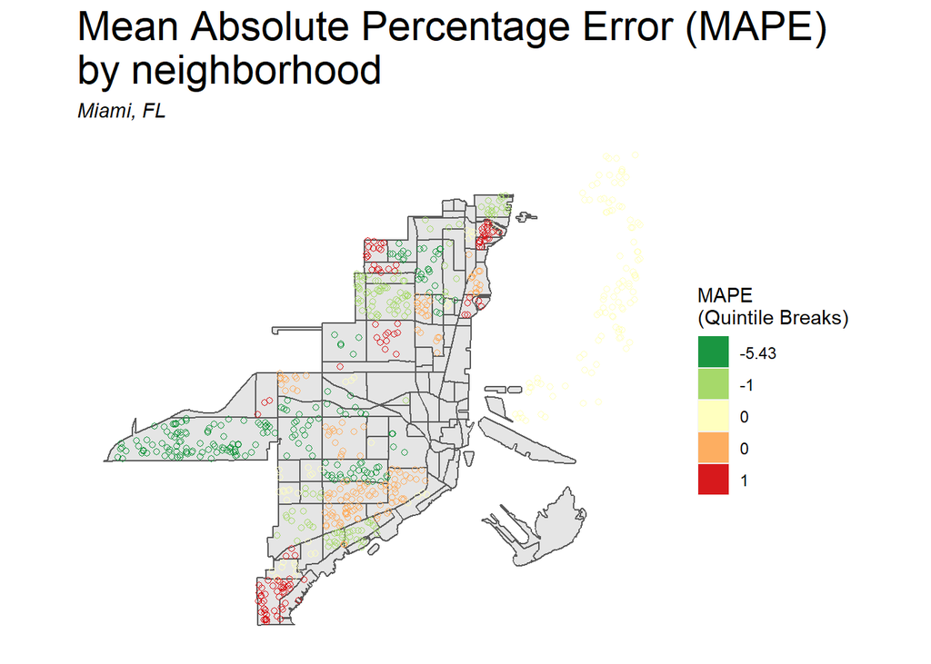

```r
ggplot() +
  geom_sf(data = neighborhoods) +
  geom_sf(data = nhood_sum, aes(fill = q5(meanMAPE), color = q5(meanMAPE))) +
  scale_fill_manual(values = rev(c("#d7191c", "#fdae61", "#ffffbf", "#a6d96a", "#1a9641")),
                    name = "MAPE\n(Quintile Breaks)",
                    labels = qBr(nhood_sum, "meanMAPE")) +
  scale_color_manual(values = rev(c("#d7191c", "#fdae61", "#ffffbf", "#a6d96a", "#1a9641")),
                     name = "MAPE\n(Quintile Breaks)",
                     labels = qBr(nhood_sum, "meanMAPE")) +
  labs(title = "Mean Absolute Percentage Error (MAPE)\nby neighborhood", subtitle = "Miami, FL") +
  mapTheme() + theme(plot.title = element_text(size=22))
```

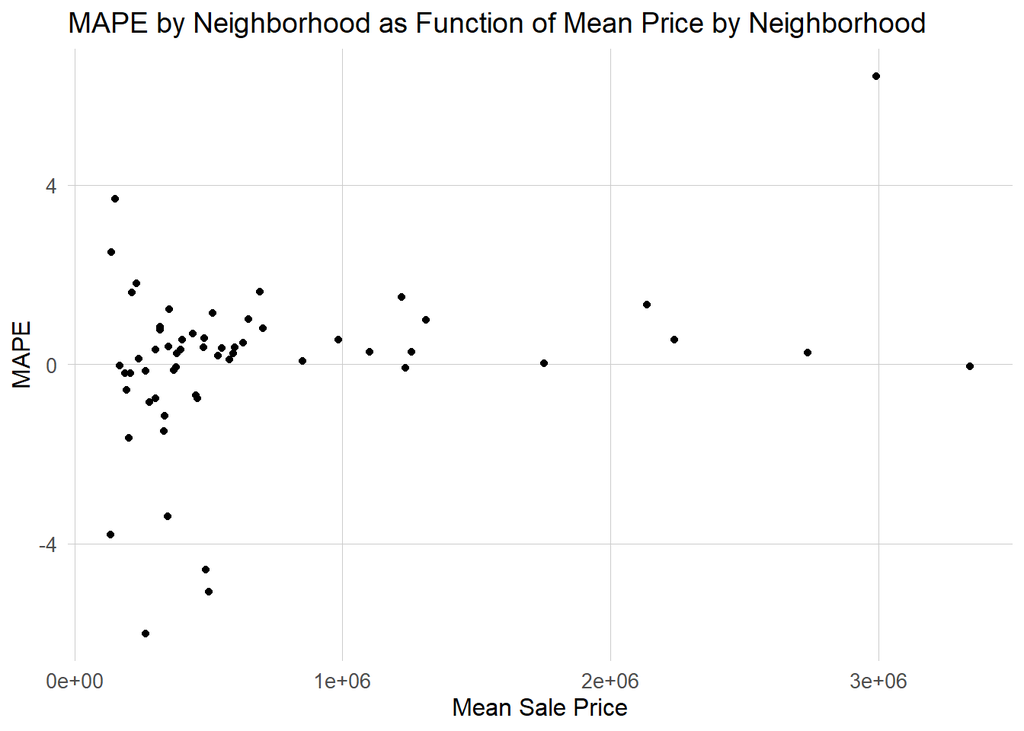

```r
#MAPE by neighborhood
nhood_sum %>%
  ggplot(aes(meanPrice, meanMAPE)) +
  geom_point() +
               labs(title = "MAPE by Neighborhood as Function of Mean Price by Neighborhood",
                    x= "Mean Sale Price",
                    y="MAPE") +
               plotTheme()
```

### Generalizability by Income and Race

Finally, can test this model’s generalizability by both race and income. Tables below show the Mean Absolute Percentage Error for different income groups and homes with majority White residents.

Because the mean average percent error for residents in majority non-white neighborhoods is negative, this means the model systematically underpredicts home values for those in non-white neighborhoods. Conversely, the model systematically over-predicts values for homes in White neighborhoods.

Because the mean percent error for residenta is positive for “High Income” groups, this means that this model systematically over-predicts home values for higher income neighborhoods and underpredicts for “Low Income” groups.

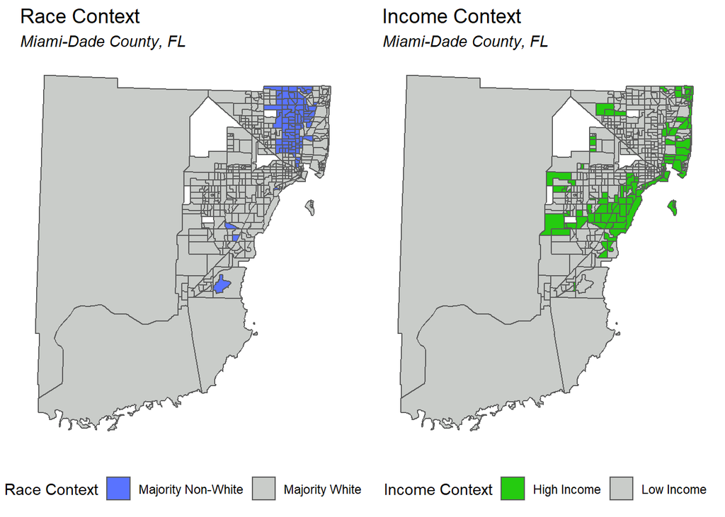

```r
tracts18_dem <-
  get_acs(geography = "tract", variables = c("B01001_001E","B01001A_001E","B06011_001"),
          year=2018, state=12, county=086, geometry=T, output = "wide") %>%
  st_transform('ESRI:102728')  %>%
  rename(TotalPop = B01001_001E,
         NumberWhites = B01001A_001E,
         Median_Income = B06011_001E) %>%
  mutate(percentWhite = NumberWhites / TotalPop,
         raceContext = ifelse(percentWhite > .5, "Majority White", "Majority Non-White"),
         incomeContext = ifelse(Median_Income > 32322, "High Income", "Low Income"))

grid.arrange(ncol = 2,
             ggplot() + geom_sf(data = na.omit(tracts18_dem), aes(fill = raceContext)) +
               scale_fill_manual(values = rev(c("#C9CCC9", "#5973ff")), name="Race Context") +
               labs(title = "Race Context", subtitle = "Miami-Dade County, FL") +
               mapTheme() + theme(legend.position="bottom"),
             ggplot() + geom_sf(data = na.omit(tracts18_dem), aes(fill = incomeContext)) +
               scale_fill_manual(values = c("#25CB10", "#C9CCC9"), name="Income Context") +
               labs(title = "Income Context", subtitle = "Miami-Dade County, FL") +
               mapTheme() + theme(legend.position="bottom"))
```

```r
miami.test.reg1$Regression <- "Regression"

library(pander)

st_join(miami.test.reg1, tracts18_dem) %>%
  group_by(Regression, raceContext) %>%
  summarize(mean.MAPE = scales::percent(mean(SalePrice.APE, na.rm = T))) %>%
  st_drop_geometry() %>%
  spread(raceContext, mean.MAPE) %>%
  pander(caption = "Test set MAPE by neighborhood racial context")
```

Test set MAPE by neighborhood racial context

| Regression | Majority Non-White | Majority White |
| --- | --- | --- |
| Regression | -25% | 10% |

```r
st_join(miami.test.reg1, tracts18_dem) %>%
  filter(!is.na(incomeContext)) %>%
  group_by(Regression, incomeContext) %>%
  summarize(mean.MAPE = scales::percent(mean(SalePrice.APE, na.rm = T))) %>%
  st_drop_geometry() %>%
  spread(incomeContext, mean.MAPE) %>%
  pander(caption = "Test set MAPE by neighborhood income context")
```

Test set MAPE by neighborhood income context

| Regression | High Income | Low Income |
| --- | --- | --- |
| Regression | 66% | -21% |

## Conclusion

Throughout this project, we have rigorously collected civic data from a variety of sources, analyzed characteristics of homes as they relate to home price, and attempted to model spatial factors that may relate to a homes value.

After this rigorous search and collection of relevant variables, we developed an algorithm and evaluated the algorithm for overall price error, as well as systematic errors as they relate to neighborhood, home value, income, and race in the city of Miami, FL.

Overall, this model has failed to pass such a rigorous test, but the methodology for testing was strong. **It is not recommended that Zillow deploy this algorithm**, but it will be imperative that, in future algorithms used by Zillow, they undergo reviews of error by all of the situations tested in this methodology. If given the opportunity to reproduce a better predictive model, it would be good for this model to incorporate more variables that impact public amenities and space throughout the city. This might include features related to zoning, local business, transportation, financial centers, or job centers.